# Assignment 9: Sentiment Analysis of Emma

Author

Anna Rescifina

## Overview

In this assignment, I use the **tidytext** framework and three sentiment lexicons (**nrc**, **afinn**, and **bing**) to explore positive and joyful words in *Emma* by Jane Austen. I first prepare and tokenize the text, then join it with each lexicon, count frequent sentiment words, and visualize the results with bar charts and word clouds.

## SetUp and Libraries Loading

## Step 1: Data wrangling

In this step I load the ‘Jane Austen’ dataset and prepare the data for analysis. I create a “linenumber” variable to track each line and a “chapter” variable by detecting chapter headings using a regular expression. Finally, I filter the dataset to keep only the book ‘Emma’.

```r
emma_lines <- austen_books() %>%
  group_by(book) %>%
  mutate(
    linenumber = row_number(),
    chapter = cumsum(str_detect(
      text,
      regex("^chapter [\\divxlc]", ignore_case = TRUE)
    ))
  ) %>%
  ungroup() %>%
  filter(book == "Emma")
```

## Step 2: Tokenization

In this step I convert the text into a tidy format using “unnest_tokens()”, where each word becomes a separate row. This format is required for sentiment analysis.

```r
emma_words <- emma_lines %>%
  unnest_tokens(word, text)
```

## Step 3: NRC Sentiment Analysis (Joy)

Using the NRC lexicon I focus specifically on words associated with the emotion joy. I join the tokenized words with the NRC dataset, count word frequencies, and keep only the most frequent words (n>50).

```r
emma_nrc <- emma_words %>%
  inner_join(
    get_sentiments("nrc") %>% filter(sentiment == "joy"),
    by = "word"
  ) %>%
  count(word, sort = TRUE) %>%
  filter(n > 50)
```

## Visualization (Bar Chart)

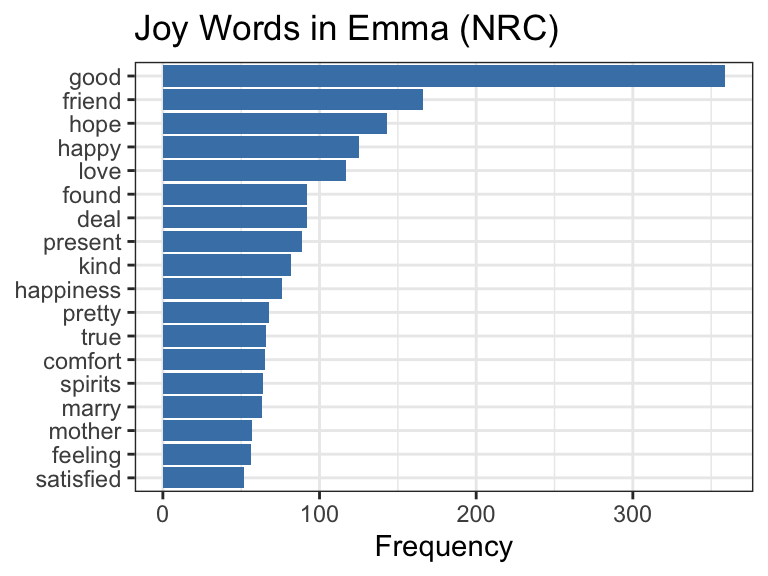

```r
emma_nrc %>%
  mutate(word = reorder(word, n)) %>%
  ggplot(aes(x = n, y = word)) +
  geom_col(fill = "steelblue") +
  labs(
    title = "Joy Words in Emma (NRC)",
    x = "Frequency",
    y = NULL
  )
```

This result suggests that positive emotional expressions are prominent throughout the text. The presence of strong positive categories such as joy indicates that the language used in the novel reflects generally optimistic or pleasant emotional tones rather than negative ones.

## Word Cloud

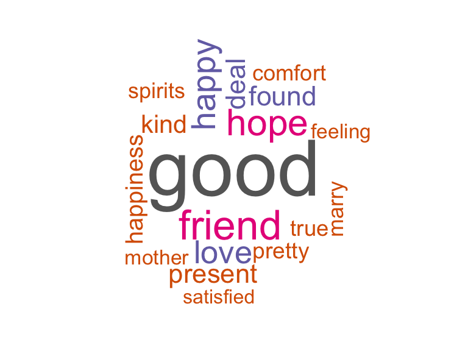

```r
wordcloud(
  words = emma_nrc$word,
  freq = emma_nrc$n,
  min.freq = 1,
  max.words = 100,
  random.order = FALSE,
  colors = brewer.pal(8, "Dark2")
)
```

## Step 3b: AFINN Sentiment Analysis (Positive)

The AFINN lexicon assigns numeric sentiment scores. In this step, I select only words with positive sentiment (Score>= 1); then count and visualize the most frequent ones.

```r
emma_afinn <- emma_words %>%
  inner_join(
    get_sentiments("afinn") %>% filter(value >= 1),
    by = "word"
  ) %>%
  count(word, sort = TRUE) %>%
  filter(n > 50)
```

## Visualization (Bar Chart)

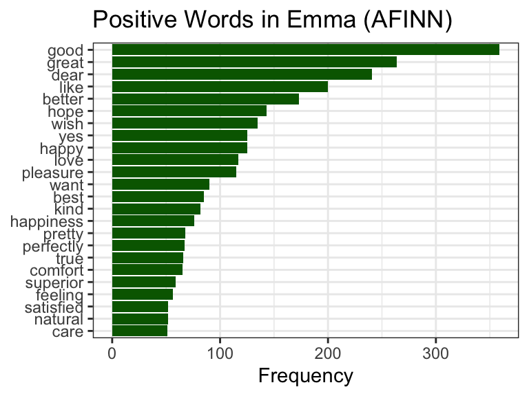

```r
emma_afinn %>%
  mutate(word = reorder(word, n)) %>%
  ggplot(aes(x = n, y = word)) +
  geom_col(fill = "darkgreen") +
  labs(
    title = "Positive Words in Emma (AFINN)",
    x = "Frequency",
    y = NULL
    )
```

## Word Cloud

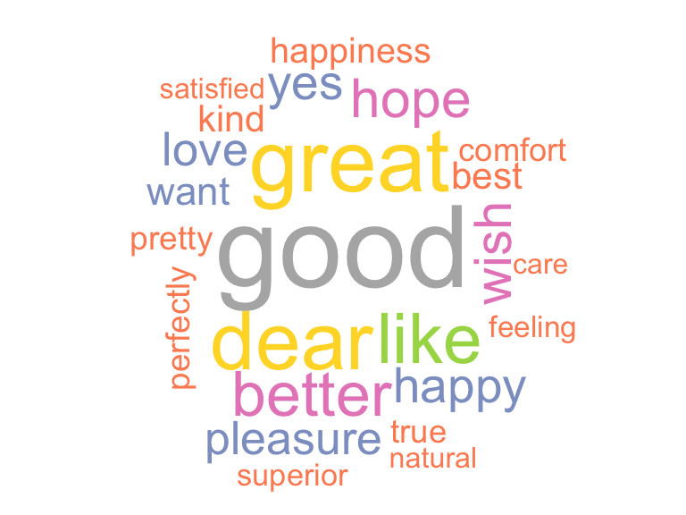

```r
wordcloud(
  words = emma_afinn$word,
  freq = emma_afinn$n,
  min.freq = 1,
  max.words = 100,
  random.order = FALSE,
  colors = brewer.pal(8, "Set2")
)
```

## Step 3c: BING Sentiment Analysis (Positive)

```r
emma_bing <- emma_words %>%
  inner_join(
    get_sentiments("bing") %>% filter(sentiment == "positive"),
    by = "word"
  ) %>%
  count(word, sort = TRUE) %>%
  filter(n > 50)
```

## Visualization (Bar Chart)

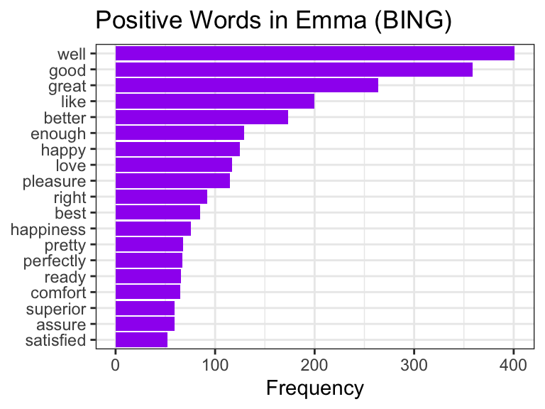

```r
emma_bing %>%
  mutate(word = reorder(word, n)) %>%
  ggplot(aes(x = n, y = word)) +
  geom_col(fill = "purple") +
  labs(
    title = "Positive Words in Emma (BING)",
    x = "Frequency",
    y = NULL
  )
```

Similar patterns appear using the BING lexicon, showing consistency across different sentiment methods

## Word Cloud

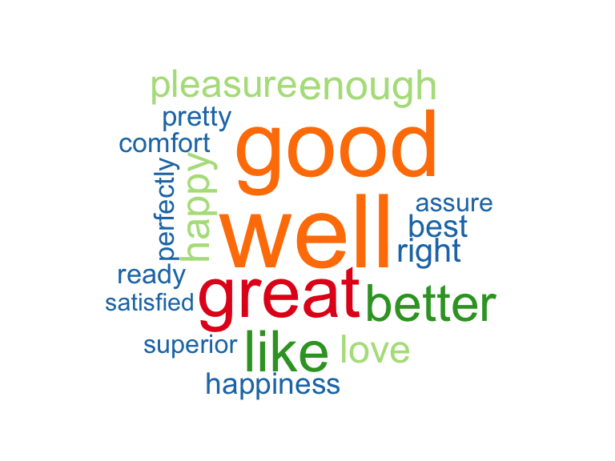

```r
wordcloud(
  words = emma_bing$word,
  freq = emma_bing$n,
  min.freq = 1,
  max.words = 100,
  random.order = FALSE,
  colors = brewer.pal(8, "Paired")
)
```

## Conclusion

Overall, the sentiment analysis of *Emma* reveals a predominantly positive emotional tone. This pattern is consistent across the NRC, AFINN, and BING lexicons, which strengthens the reliability of the findings. The agreement across multiple methods suggests that the results are not dependent on a single approach, but instead reflect a consistent characteristic of the text. This indicates that the language used throughout the novel conveys generally positive emotions and attitudes